# Risk Factor Analysis

## Outcome Variable

**Outcome Variable:** ever_sstunted

## Predictor Variables

**Intervention Variable:** mage

**Adjustment Set:**

- arm
- meducyrs
- feducyrs
- W_mhtcm
- W_mwtkg
- W_mbmi
- single
- delta_meducyrs
- delta_feducyrs
- delta_W_mhtcm
- delta_W_mwtkg
- delta_W_mbmi
- delta_single

## Stratifying Variables

The analysis was stratified on these variable(s):

- agecat
- studyid
- country

## Data Summary

| agecat | studyid | country | mage | ever_sstunted | n_cell | n |
| --- | --- | --- | --- | --- | --- | --- |
| 0-24 months | CMC-V-BCS-2002 | INDIA | [20-30) | 0 | 106 | 373 |
| 0-24 months | CMC-V-BCS-2002 | INDIA | [20-30) | 1 | 190 | 373 |
| 0-24 months | CMC-V-BCS-2002 | INDIA | <20 | 0 | 13 | 373 |
| 0-24 months | CMC-V-BCS-2002 | INDIA | <20 | 1 | 21 | 373 |
| 0-24 months | CMC-V-BCS-2002 | INDIA | >=30 | 0 | 17 | 373 |
| 0-24 months | CMC-V-BCS-2002 | INDIA | >=30 | 1 | 26 | 373 |
| 0-24 months | COHORTS | GUATEMALA | [20-30) | 0 | 354 | 1360 |
| 0-24 months | COHORTS | GUATEMALA | [20-30) | 1 | 307 | 1360 |
| 0-24 months | COHORTS | GUATEMALA | <20 | 0 | 111 | 1360 |
| 0-24 months | COHORTS | GUATEMALA | <20 | 1 | 91 | 1360 |
| 0-24 months | COHORTS | GUATEMALA | >=30 | 0 | 264 | 1360 |
| 0-24 months | COHORTS | GUATEMALA | >=30 | 1 | 233 | 1360 |
| 0-24 months | COHORTS | INDIA | [20-30) | 0 | 3140 | 5313 |
| 0-24 months | COHORTS | INDIA | [20-30) | 1 | 462 | 5313 |
| 0-24 months | COHORTS | INDIA | <20 | 0 | 368 | 5313 |
| 0-24 months | COHORTS | INDIA | <20 | 1 | 59 | 5313 |
| 0-24 months | COHORTS | INDIA | >=30 | 0 | 1077 | 5313 |
| 0-24 months | COHORTS | INDIA | >=30 | 1 | 207 | 5313 |
| 0-24 months | COHORTS | PHILIPPINES | [20-30) | 0 | 1230 | 3058 |
| 0-24 months | COHORTS | PHILIPPINES | [20-30) | 1 | 597 | 3058 |
| 0-24 months | COHORTS | PHILIPPINES | <20 | 0 | 231 | 3058 |
| 0-24 months | COHORTS | PHILIPPINES | <20 | 1 | 147 | 3058 |
| 0-24 months | COHORTS | PHILIPPINES | >=30 | 0 | 508 | 3058 |
| 0-24 months | COHORTS | PHILIPPINES | >=30 | 1 | 345 | 3058 |
| 0-24 months | EE | PAKISTAN | [20-30) | 0 | 65 | 377 |
| 0-24 months | EE | PAKISTAN | [20-30) | 1 | 97 | 377 |
| 0-24 months | EE | PAKISTAN | <20 | 0 | 0 | 377 |
| 0-24 months | EE | PAKISTAN | <20 | 1 | 1 | 377 |
| 0-24 months | EE | PAKISTAN | >=30 | 0 | 85 | 377 |
| 0-24 months | EE | PAKISTAN | >=30 | 1 | 129 | 377 |

[output cut: 132 more lines]

The following strata were considered:

- agecat: 0-24 months, studyid: CMC-V-BCS-2002, country: INDIA
- agecat: 0-24 months, studyid: COHORTS, country: GUATEMALA
- agecat: 0-24 months, studyid: COHORTS, country: INDIA
- agecat: 0-24 months, studyid: COHORTS, country: PHILIPPINES
- agecat: 0-24 months, studyid: EE, country: PAKISTAN
- agecat: 0-24 months, studyid: GMS-Nepal, country: NEPAL
- agecat: 0-24 months, studyid: Guatemala BSC, country: GUATEMALA
- agecat: 0-24 months, studyid: iLiNS-Zinc, country: BURKINA FASO
- agecat: 0-24 months, studyid: IRC, country: INDIA
- agecat: 0-24 months, studyid: JiVitA-3, country: BANGLADESH
- agecat: 0-24 months, studyid: Keneba, country: GAMBIA
- agecat: 0-24 months, studyid: LCNI-5, country: MALAWI
- agecat: 0-24 months, studyid: MAL-ED, country: BANGLADESH
- agecat: 0-24 months, studyid: MAL-ED, country: BRAZIL
- agecat: 0-24 months, studyid: MAL-ED, country: INDIA
- agecat: 0-24 months, studyid: MAL-ED, country: NEPAL
- agecat: 0-24 months, studyid: MAL-ED, country: PERU
- agecat: 0-24 months, studyid: MAL-ED, country: SOUTH AFRICA
- agecat: 0-24 months, studyid: MAL-ED, country: TANZANIA, UNITED REPUBLIC OF
- agecat: 0-24 months, studyid: NIH-Birth, country: BANGLADESH
- agecat: 0-24 months, studyid: NIH-Crypto, country: BANGLADESH
- agecat: 0-24 months, studyid: PROBIT, country: BELARUS
- agecat: 0-24 months, studyid: PROVIDE, country: BANGLADESH
- agecat: 0-24 months, studyid: SAS-CompFeed, country: INDIA
- agecat: 0-24 months, studyid: SAS-FoodSuppl, country: INDIA
- agecat: 0-24 months, studyid: TanzaniaChild2, country: TANZANIA, UNITED REPUBLIC OF
- agecat: 0-24 months, studyid: ZVITAMBO, country: ZIMBABWE

### Dropped Strata

Some strata were dropped due to rare outcomes:

- agecat: 0-24 months, studyid: EE, country: PAKISTAN
- agecat: 0-24 months, studyid: MAL-ED, country: BRAZIL
- agecat: 0-24 months, studyid: MAL-ED, country: INDIA
- agecat: 0-24 months, studyid: MAL-ED, country: NEPAL

## Methods Detail

We're interested in the causal parameters $E[Y_a]$ for all values of $a \in \mathcal{A}$. These parameters represent the mean outcome if, possibly contrary to fact, we intervened to set all units to have $A=a$. Under the randomization and positivity assumptions, these are identified by the statistical parameters $\psi_a=E_W[E_{Y|A,W}(Y|A=a,W)]$. In addition, we're interested in the mean of $Y$, $E[Y]$ under no intervention (the observed mean). We will estimate these parameters by using SuperLearner to fit the relevant likelihood factors -- $E_{Y|A,W}(Y|A=a,W)$ and $p(A=a|W)$, and then updating our likelihood fit using a joint TMLE.

For unadjusted analyses ($W=\{\}$), initial likelihoods were estimated using Lrnr_glm to estimate the simple $E(Y|A)$ and Lrnr_mean to estimate $p(A)$. For adjusted analyses, a small library containing Lrnr_glmnet, Lrnr_xgboost, and Lrnr_mean was used.

Having estimated these parameters, we will then use the delta method to estimate relative risks and attributable risks relative to a prespecified baseline level of $A$.

# Results Detail

## Results Plots

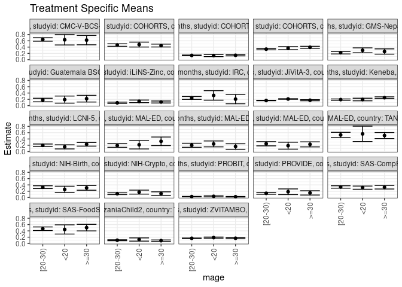

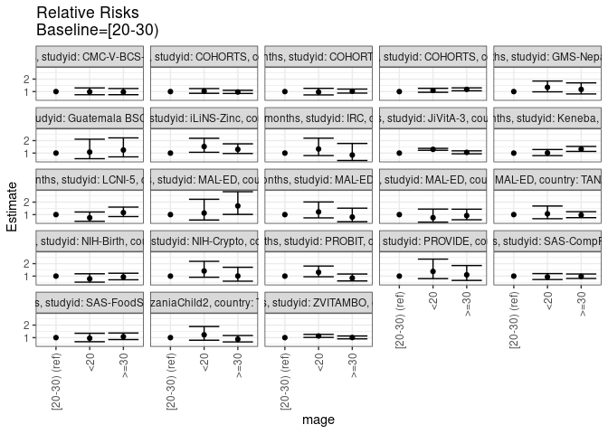

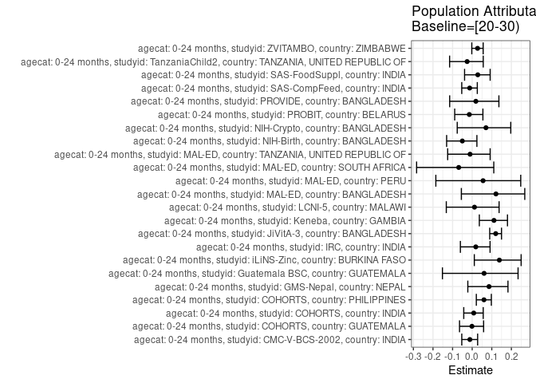

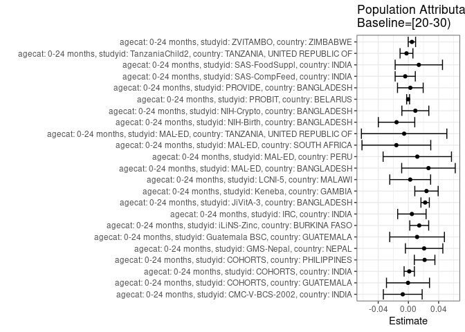

## Results Table

### Parameter: TSM

| agecat | studyid | country | intervention_level | baseline_level | estimate | ci_lower | ci_upper |
| --- | --- | --- | --- | --- | --- | --- | --- |
| 0-24 months | CMC-V-BCS-2002 | INDIA | [20-30) | NA | 0.6428925 | 0.5879861 | 0.6977990 |
| 0-24 months | CMC-V-BCS-2002 | INDIA | <20 | NA | 0.6321503 | 0.4676496 | 0.7966510 |
| 0-24 months | CMC-V-BCS-2002 | INDIA | >=30 | NA | 0.6211941 | 0.4735875 | 0.7688008 |
| 0-24 months | COHORTS | GUATEMALA | [20-30) | NA | 0.4645216 | 0.4253035 | 0.5037396 |
| 0-24 months | COHORTS | GUATEMALA | <20 | NA | 0.4803428 | 0.4025670 | 0.5581186 |
| 0-24 months | COHORTS | GUATEMALA | >=30 | NA | 0.4494051 | 0.4036412 | 0.4951689 |
| 0-24 months | COHORTS | INDIA | [20-30) | NA | 0.1359253 | 0.1245702 | 0.1472804 |
| 0-24 months | COHORTS | INDIA | <20 | NA | 0.1309070 | 0.0973244 | 0.1644895 |
| 0-24 months | COHORTS | INDIA | >=30 | NA | 0.1395982 | 0.1209149 | 0.1582814 |
| 0-24 months | COHORTS | PHILIPPINES | [20-30) | NA | 0.3346576 | 0.3131384 | 0.3561769 |
| 0-24 months | COHORTS | PHILIPPINES | <20 | NA | 0.3652794 | 0.3173355 | 0.4132234 |
| 0-24 months | COHORTS | PHILIPPINES | >=30 | NA | 0.3932865 | 0.3621479 | 0.4244252 |
| 0-24 months | GMS-Nepal | NEPAL | [20-30) | NA | 0.2213195 | 0.1823660 | 0.2602730 |
| 0-24 months | GMS-Nepal | NEPAL | <20 | NA | 0.2973463 | 0.2191234 | 0.3755691 |
| 0-24 months | GMS-Nepal | NEPAL | >=30 | NA | 0.2596031 | 0.1756570 | 0.3435492 |
| 0-24 months | Guatemala BSC | GUATEMALA | [20-30) | NA | 0.1771429 | 0.1204762 | 0.2338095 |
| 0-24 months | Guatemala BSC | GUATEMALA | <20 | NA | 0.1914894 | 0.0787986 | 0.3041802 |
| 0-24 months | Guatemala BSC | GUATEMALA | >=30 | NA | 0.2203390 | 0.1143905 | 0.3262875 |
| 0-24 months | iLiNS-Zinc | BURKINA FASO | [20-30) | NA | 0.0889006 | 0.0675800 | 0.1102213 |
| 0-24 months | iLiNS-Zinc | BURKINA FASO | <20 | NA | 0.1355572 | 0.0939481 | 0.1771664 |
| 0-24 months | iLiNS-Zinc | BURKINA FASO | >=30 | NA | 0.1153603 | 0.0839127 | 0.1468080 |
| 0-24 months | IRC | INDIA | [20-30) | NA | 0.2441860 | 0.1987326 | 0.2896395 |
| 0-24 months | IRC | INDIA | <20 | NA | 0.3243243 | 0.1733036 | 0.4753450 |
| 0-24 months | IRC | INDIA | >=30 | NA | 0.2068966 | 0.0592848 | 0.3545083 |
| 0-24 months | JiVitA-3 | BANGLADESH | [20-30) | NA | 0.1622289 | 0.1546116 | 0.1698462 |
| 0-24 months | JiVitA-3 | BANGLADESH | <20 | NA | 0.2106152 | 0.2019401 | 0.2192903 |
| 0-24 months | JiVitA-3 | BANGLADESH | >=30 | NA | 0.1712807 | 0.1536346 | 0.1889269 |
| 0-24 months | Keneba | GAMBIA | [20-30) | NA | 0.1911843 | 0.1703865 | 0.2119822 |
| 0-24 months | Keneba | GAMBIA | <20 | NA | 0.1940022 | 0.1528895 | 0.2351149 |
| 0-24 months | Keneba | GAMBIA | >=30 | NA | 0.2520038 | 0.2255210 | 0.2784866 |
| 0-24 months | LCNI-5 | MALAWI | [20-30) | NA | 0.1991187 | 0.1584452 | 0.2397922 |
| 0-24 months | LCNI-5 | MALAWI | <20 | NA | 0.1491876 | 0.0840023 | 0.2143730 |
| 0-24 months | LCNI-5 | MALAWI | >=30 | NA | 0.2313208 | 0.1731338 | 0.2895078 |
| 0-24 months | MAL-ED | BANGLADESH | [20-30) | NA | 0.1923077 | 0.1349417 | 0.2496737 |
| 0-24 months | MAL-ED | BANGLADESH | <20 | NA | 0.2162162 | 0.0833207 | 0.3491118 |
| 0-24 months | MAL-ED | BANGLADESH | >=30 | NA | 0.3260870 | 0.1903623 | 0.4618116 |
| 0-24 months | MAL-ED | PERU | [20-30) | NA | 0.1994632 | 0.1348436 | 0.2640827 |
| 0-24 months | MAL-ED | PERU | <20 | NA | 0.2430437 | 0.1491466 | 0.3369409 |
| 0-24 months | MAL-ED | PERU | >=30 | NA | 0.1604559 | 0.0726295 | 0.2482823 |
| 0-24 months | MAL-ED | SOUTH AFRICA | [20-30) | NA | 0.2484472 | 0.1815936 | 0.3153008 |
| 0-24 months | MAL-ED | SOUTH AFRICA | <20 | NA | 0.1875000 | 0.0769058 | 0.2980942 |
| 0-24 months | MAL-ED | SOUTH AFRICA | >=30 | NA | 0.2285714 | 0.1481253 | 0.3090175 |
| 0-24 months | MAL-ED | TANZANIA, UNITED REPUBLIC OF | [20-30) | NA | 0.5285714 | 0.4457249 | 0.6114179 |
| 0-24 months | MAL-ED | TANZANIA, UNITED REPUBLIC OF | <20 | NA | 0.5625000 | 0.3189609 | 0.8060391 |
| 0-24 months | MAL-ED | TANZANIA, UNITED REPUBLIC OF | >=30 | NA | 0.5094340 | 0.4140845 | 0.6047834 |
| 0-24 months | NIH-Birth | BANGLADESH | [20-30) | NA | 0.3283298 | 0.2838130 | 0.3728466 |
| 0-24 months | NIH-Birth | BANGLADESH | <20 | NA | 0.2578322 | 0.1568573 | 0.3588070 |
| 0-24 months | NIH-Birth | BANGLADESH | >=30 | NA | 0.3063657 | 0.2314347 | 0.3812967 |
| 0-24 months | NIH-Crypto | BANGLADESH | [20-30) | NA | 0.1214263 | 0.0927147 | 0.1501378 |
| 0-24 months | NIH-Crypto | BANGLADESH | <20 | NA | 0.1711743 | 0.1079192 | 0.2344293 |
| 0-24 months | NIH-Crypto | BANGLADESH | >=30 | NA | 0.1224197 | 0.0645364 | 0.1803029 |
| 0-24 months | PROBIT | BELARUS | [20-30) | NA | 0.0280430 | 0.0210146 | 0.0350713 |
| 0-24 months | PROBIT | BELARUS | <20 | NA | 0.0367138 | 0.0212935 | 0.0521341 |
| 0-24 months | PROBIT | BELARUS | >=30 | NA | 0.0237185 | 0.0145970 | 0.0328400 |
| 0-24 months | PROVIDE | BANGLADESH | [20-30) | NA | 0.1331668 | 0.1028897 | 0.1634440 |
| 0-24 months | PROVIDE | BANGLADESH | <20 | NA | 0.1831335 | 0.0932380 | 0.2730289 |
| 0-24 months | PROVIDE | BANGLADESH | >=30 | NA | 0.1465855 | 0.0784309 | 0.2147401 |
| 0-24 months | SAS-CompFeed | INDIA | [20-30) | NA | 0.3349476 | 0.2969125 | 0.3729826 |
| 0-24 months | SAS-CompFeed | INDIA | <20 | NA | 0.3129982 | 0.2618923 | 0.3641041 |
| 0-24 months | SAS-CompFeed | INDIA | >=30 | NA | 0.3269459 | 0.2698980 | 0.3839939 |
| 0-24 months | SAS-FoodSuppl | INDIA | [20-30) | NA | 0.4670753 | 0.4099614 | 0.5241892 |
| 0-24 months | SAS-FoodSuppl | INDIA | <20 | NA | 0.4449842 | 0.2988925 | 0.5910759 |
| 0-24 months | SAS-FoodSuppl | INDIA | >=30 | NA | 0.5027511 | 0.3984830 | 0.6070193 |
| 0-24 months | TanzaniaChild2 | TANZANIA, UNITED REPUBLIC OF | [20-30) | NA | 0.1018813 | 0.0868926 | 0.1168701 |
| 0-24 months | TanzaniaChild2 | TANZANIA, UNITED REPUBLIC OF | <20 | NA | 0.1247460 | 0.0738566 | 0.1756353 |
| 0-24 months | TanzaniaChild2 | TANZANIA, UNITED REPUBLIC OF | >=30 | NA | 0.0891150 | 0.0668799 | 0.1113501 |
| 0-24 months | ZVITAMBO | ZIMBABWE | [20-30) | NA | 0.1633969 | 0.1555925 | 0.1712014 |
| 0-24 months | ZVITAMBO | ZIMBABWE | <20 | NA | 0.1850547 | 0.1673076 | 0.2028018 |
| 0-24 months | ZVITAMBO | ZIMBABWE | >=30 | NA | 0.1650963 | 0.1482473 | 0.1819453 |

### Parameter: E(Y)

| agecat | studyid | country | intervention_level | baseline_level | estimate | ci_lower | ci_upper |
| --- | --- | --- | --- | --- | --- | --- | --- |
| 0-24 months | CMC-V-BCS-2002 | INDIA | NA | NA | 0.6353887 | 0.5864772 | 0.6843003 |
| 0-24 months | COHORTS | GUATEMALA | NA | NA | 0.4639706 | 0.4374564 | 0.4904847 |
| 0-24 months | COHORTS | INDIA | NA | NA | 0.1370224 | 0.1277751 | 0.1462697 |
| 0-24 months | COHORTS | PHILIPPINES | NA | NA | 0.3561151 | 0.3391405 | 0.3730897 |
| 0-24 months | GMS-Nepal | NEPAL | NA | NA | 0.2421203 | 0.2103189 | 0.2739218 |
| 0-24 months | Guatemala BSC | GUATEMALA | NA | NA | 0.1886121 | 0.1427907 | 0.2344335 |
| 0-24 months | iLiNS-Zinc | BURKINA FASO | NA | NA | 0.1032096 | 0.0833330 | 0.1230861 |
| 0-24 months | IRC | INDIA | NA | NA | 0.2487805 | 0.2068840 | 0.2906770 |
| 0-24 months | JiVitA-3 | BANGLADESH | NA | NA | 0.1843768 | 0.1787788 | 0.1899748 |
| 0-24 months | Keneba | GAMBIA | NA | NA | 0.2151102 | 0.2000458 | 0.2301746 |
| 0-24 months | LCNI-5 | MALAWI | NA | NA | 0.2014925 | 0.1710974 | 0.2318877 |
| 0-24 months | MAL-ED | BANGLADESH | NA | NA | 0.2188679 | 0.1689910 | 0.2687448 |
| 0-24 months | MAL-ED | PERU | NA | NA | 0.2112211 | 0.1651858 | 0.2572564 |
| 0-24 months | MAL-ED | SOUTH AFRICA | NA | NA | 0.2324841 | 0.1856873 | 0.2792809 |
| 0-24 months | MAL-ED | TANZANIA, UNITED REPUBLIC OF | NA | NA | 0.5229008 | 0.4623051 | 0.5834965 |
| 0-24 months | NIH-Birth | BANGLADESH | NA | NA | 0.3125997 | 0.2762869 | 0.3489125 |
| 0-24 months | NIH-Crypto | BANGLADESH | NA | NA | 0.1306069 | 0.1066024 | 0.1546113 |
| 0-24 months | PROBIT | BELARUS | NA | NA | 0.0276380 | 0.0201988 | 0.0350773 |
| 0-24 months | PROVIDE | BANGLADESH | NA | NA | 0.1357143 | 0.1103250 | 0.1611036 |
| 0-24 months | SAS-CompFeed | INDIA | NA | NA | 0.3307241 | 0.3024794 | 0.3589688 |
| 0-24 months | SAS-FoodSuppl | INDIA | NA | NA | 0.4808612 | 0.4329065 | 0.5288160 |
| 0-24 months | TanzaniaChild2 | TANZANIA, UNITED REPUBLIC OF | NA | NA | 0.0993266 | 0.0872975 | 0.1113557 |
| 0-24 months | ZVITAMBO | ZIMBABWE | NA | NA | 0.1680205 | 0.1618345 | 0.1742065 |

### Parameter: RR

| agecat | studyid | country | intervention_level | baseline_level | estimate | ci_lower | ci_upper |
| --- | --- | --- | --- | --- | --- | --- | --- |
| 0-24 months | CMC-V-BCS-2002 | INDIA | [20-30) | [20-30) | 1.0000000 | 1.0000000 | 1.000000 |
| 0-24 months | CMC-V-BCS-2002 | INDIA | <20 | [20-30) | 0.9832908 | 0.7474155 | 1.293606 |
| 0-24 months | CMC-V-BCS-2002 | INDIA | >=30 | [20-30) | 0.9662488 | 0.7505436 | 1.243947 |
| 0-24 months | COHORTS | GUATEMALA | [20-30) | [20-30) | 1.0000000 | 1.0000000 | 1.000000 |
| 0-24 months | COHORTS | GUATEMALA | <20 | [20-30) | 1.0340592 | 0.8620923 | 1.240329 |
| 0-24 months | COHORTS | GUATEMALA | >=30 | [20-30) | 0.9674578 | 0.8489355 | 1.102527 |
| 0-24 months | COHORTS | INDIA | [20-30) | [20-30) | 1.0000000 | 1.0000000 | 1.000000 |
| 0-24 months | COHORTS | INDIA | <20 | [20-30) | 0.9630800 | 0.7356362 | 1.260845 |
| 0-24 months | COHORTS | INDIA | >=30 | [20-30) | 1.0270210 | 0.8782125 | 1.201044 |
| 0-24 months | COHORTS | PHILIPPINES | [20-30) | [20-30) | 1.0000000 | 1.0000000 | 1.000000 |
| 0-24 months | COHORTS | PHILIPPINES | <20 | [20-30) | 1.0915019 | 0.9445285 | 1.261345 |
| 0-24 months | COHORTS | PHILIPPINES | >=30 | [20-30) | 1.1751907 | 1.0636418 | 1.298438 |
| 0-24 months | GMS-Nepal | NEPAL | [20-30) | [20-30) | 1.0000000 | 1.0000000 | 1.000000 |
| 0-24 months | GMS-Nepal | NEPAL | <20 | [20-30) | 1.3435158 | 0.9790093 | 1.843736 |
| 0-24 months | GMS-Nepal | NEPAL | >=30 | [20-30) | 1.1729789 | 0.8115970 | 1.695274 |
| 0-24 months | Guatemala BSC | GUATEMALA | [20-30) | [20-30) | 1.0000000 | 1.0000000 | 1.000000 |
| 0-24 months | Guatemala BSC | GUATEMALA | <20 | [20-30) | 1.0809883 | 0.5532505 | 2.112128 |
| 0-24 months | Guatemala BSC | GUATEMALA | >=30 | [20-30) | 1.2438491 | 0.6981512 | 2.216082 |
| 0-24 months | iLiNS-Zinc | BURKINA FASO | [20-30) | [20-30) | 1.0000000 | 1.0000000 | 1.000000 |
| 0-24 months | iLiNS-Zinc | BURKINA FASO | <20 | [20-30) | 1.5248175 | 1.0637290 | 2.185771 |
| 0-24 months | iLiNS-Zinc | BURKINA FASO | >=30 | [20-30) | 1.2976320 | 0.9670492 | 1.741223 |
| 0-24 months | IRC | INDIA | [20-30) | [20-30) | 1.0000000 | 1.0000000 | 1.000000 |
| 0-24 months | IRC | INDIA | <20 | [20-30) | 1.3281853 | 0.8043984 | 2.193038 |
| 0-24 months | IRC | INDIA | >=30 | [20-30) | 0.8472906 | 0.4053311 | 1.771148 |
| 0-24 months | JiVitA-3 | BANGLADESH | [20-30) | [20-30) | 1.0000000 | 1.0000000 | 1.000000 |
| 0-24 months | JiVitA-3 | BANGLADESH | <20 | [20-30) | 1.2982595 | 1.2242802 | 1.376709 |
| 0-24 months | JiVitA-3 | BANGLADESH | >=30 | [20-30) | 1.0557968 | 0.9453532 | 1.179143 |
| 0-24 months | Keneba | GAMBIA | [20-30) | [20-30) | 1.0000000 | 1.0000000 | 1.000000 |
| 0-24 months | Keneba | GAMBIA | <20 | [20-30) | 1.0147389 | 0.7998560 | 1.287351 |
| 0-24 months | Keneba | GAMBIA | >=30 | [20-30) | 1.3181194 | 1.1342564 | 1.531787 |
| 0-24 months | LCNI-5 | MALAWI | [20-30) | [20-30) | 1.0000000 | 1.0000000 | 1.000000 |
| 0-24 months | LCNI-5 | MALAWI | <20 | [20-30) | 0.7492396 | 0.4646225 | 1.208207 |
| 0-24 months | LCNI-5 | MALAWI | >=30 | [20-30) | 1.1617231 | 0.8435080 | 1.599986 |
| 0-24 months | MAL-ED | BANGLADESH | [20-30) | [20-30) | 1.0000000 | 1.0000000 | 1.000000 |
| 0-24 months | MAL-ED | BANGLADESH | <20 | [20-30) | 1.1243243 | 0.5677789 | 2.226404 |
| 0-24 months | MAL-ED | BANGLADESH | >=30 | [20-30) | 1.6956522 | 1.0161160 | 2.829634 |
| 0-24 months | MAL-ED | PERU | [20-30) | [20-30) | 1.0000000 | 1.0000000 | 1.000000 |
| 0-24 months | MAL-ED | PERU | <20 | [20-30) | 1.2184893 | 0.7377077 | 2.012608 |
| 0-24 months | MAL-ED | PERU | >=30 | [20-30) | 0.8044385 | 0.4269949 | 1.515525 |
| 0-24 months | MAL-ED | SOUTH AFRICA | [20-30) | [20-30) | 1.0000000 | 1.0000000 | 1.000000 |
| 0-24 months | MAL-ED | SOUTH AFRICA | <20 | [20-30) | 0.7546875 | 0.3946455 | 1.443202 |
| 0-24 months | MAL-ED | SOUTH AFRICA | >=30 | [20-30) | 0.9200000 | 0.5907199 | 1.432828 |
| 0-24 months | MAL-ED | TANZANIA, UNITED REPUBLIC OF | [20-30) | [20-30) | 1.0000000 | 1.0000000 | 1.000000 |
| 0-24 months | MAL-ED | TANZANIA, UNITED REPUBLIC OF | <20 | [20-30) | 1.0641892 | 0.6714992 | 1.686523 |
| 0-24 months | MAL-ED | TANZANIA, UNITED REPUBLIC OF | >=30 | [20-30) | 0.9637940 | 0.7550247 | 1.230289 |
| 0-24 months | NIH-Birth | BANGLADESH | [20-30) | [20-30) | 1.0000000 | 1.0000000 | 1.000000 |
| 0-24 months | NIH-Birth | BANGLADESH | <20 | [20-30) | 0.7852842 | 0.5196805 | 1.186635 |
| 0-24 months | NIH-Birth | BANGLADESH | >=30 | [20-30) | 0.9331035 | 0.7076677 | 1.230354 |
| 0-24 months | NIH-Crypto | BANGLADESH | [20-30) | [20-30) | 1.0000000 | 1.0000000 | 1.000000 |
| 0-24 months | NIH-Crypto | BANGLADESH | <20 | [20-30) | 1.4096973 | 0.9104954 | 2.182599 |
| 0-24 months | NIH-Crypto | BANGLADESH | >=30 | [20-30) | 1.0081811 | 0.5951319 | 1.707906 |
| 0-24 months | PROBIT | BELARUS | [20-30) | [20-30) | 1.0000000 | 1.0000000 | 1.000000 |
| 0-24 months | PROBIT | BELARUS | <20 | [20-30) | 1.3091980 | 0.9486721 | 1.806735 |
| 0-24 months | PROBIT | BELARUS | >=30 | [20-30) | 0.8457924 | 0.6129034 | 1.167174 |
| 0-24 months | PROVIDE | BANGLADESH | [20-30) | [20-30) | 1.0000000 | 1.0000000 | 1.000000 |
| 0-24 months | PROVIDE | BANGLADESH | <20 | [20-30) | 1.3752183 | 0.8013693 | 2.359992 |
| 0-24 months | PROVIDE | BANGLADESH | >=30 | [20-30) | 1.1007659 | 0.6558913 | 1.847388 |
| 0-24 months | SAS-CompFeed | INDIA | [20-30) | [20-30) | 1.0000000 | 1.0000000 | 1.000000 |
| 0-24 months | SAS-CompFeed | INDIA | <20 | [20-30) | 0.9344692 | 0.7267591 | 1.201544 |
| 0-24 months | SAS-CompFeed | INDIA | >=30 | [20-30) | 0.9761108 | 0.8146353 | 1.169594 |
| 0-24 months | SAS-FoodSuppl | INDIA | [20-30) | [20-30) | 1.0000000 | 1.0000000 | 1.000000 |
| 0-24 months | SAS-FoodSuppl | INDIA | <20 | [20-30) | 0.9527034 | 0.6733969 | 1.347859 |
| 0-24 months | SAS-FoodSuppl | INDIA | >=30 | [20-30) | 1.0763814 | 0.8469574 | 1.367952 |
| 0-24 months | TanzaniaChild2 | TANZANIA, UNITED REPUBLIC OF | [20-30) | [20-30) | 1.0000000 | 1.0000000 | 1.000000 |
| 0-24 months | TanzaniaChild2 | TANZANIA, UNITED REPUBLIC OF | <20 | [20-30) | 1.2244243 | 0.7937748 | 1.888715 |
| 0-24 months | TanzaniaChild2 | TANZANIA, UNITED REPUBLIC OF | >=30 | [20-30) | 0.8746942 | 0.6549760 | 1.168119 |
| 0-24 months | ZVITAMBO | ZIMBABWE | [20-30) | [20-30) | 1.0000000 | 1.0000000 | 1.000000 |
| 0-24 months | ZVITAMBO | ZIMBABWE | <20 | [20-30) | 1.1325469 | 1.0177198 | 1.260330 |
| 0-24 months | ZVITAMBO | ZIMBABWE | >=30 | [20-30) | 1.0104004 | 0.9030357 | 1.130530 |

### Parameter: PAR

| agecat | studyid | country | intervention_level | baseline_level | estimate | ci_lower | ci_upper |
| --- | --- | --- | --- | --- | --- | --- | --- |
| 0-24 months | CMC-V-BCS-2002 | INDIA | [20-30) | NA | -0.0075038 | -0.0331956 | 0.0181881 |
| 0-24 months | COHORTS | GUATEMALA | [20-30) | NA | -0.0005510 | -0.0290461 | 0.0279441 |
| 0-24 months | COHORTS | INDIA | [20-30) | NA | 0.0010971 | -0.0057129 | 0.0079070 |
| 0-24 months | COHORTS | PHILIPPINES | [20-30) | NA | 0.0214575 | 0.0078321 | 0.0350829 |
| 0-24 months | GMS-Nepal | NEPAL | [20-30) | NA | 0.0208008 | -0.0039841 | 0.0455858 |
| 0-24 months | Guatemala BSC | GUATEMALA | [20-30) | NA | 0.0114692 | -0.0247400 | 0.0476784 |
| 0-24 months | iLiNS-Zinc | BURKINA FASO | [20-30) | NA | 0.0143089 | 0.0017764 | 0.0268415 |
| 0-24 months | IRC | INDIA | [20-30) | NA | 0.0045944 | -0.0142326 | 0.0234215 |
| 0-24 months | JiVitA-3 | BANGLADESH | [20-30) | NA | 0.0221479 | 0.0166042 | 0.0276917 |
| 0-24 months | Keneba | GAMBIA | [20-30) | NA | 0.0239258 | 0.0084642 | 0.0393874 |
| 0-24 months | LCNI-5 | MALAWI | [20-30) | NA | 0.0023738 | -0.0246801 | 0.0294278 |
| 0-24 months | MAL-ED | BANGLADESH | [20-30) | NA | 0.0265602 | -0.0089121 | 0.0620326 |
| 0-24 months | MAL-ED | PERU | [20-30) | NA | 0.0117580 | -0.0335214 | 0.0570373 |
| 0-24 months | MAL-ED | SOUTH AFRICA | [20-30) | NA | -0.0159631 | -0.0615271 | 0.0296008 |
| 0-24 months | MAL-ED | TANZANIA, UNITED REPUBLIC OF | [20-30) | NA | -0.0056707 | -0.0622418 | 0.0509005 |
| 0-24 months | NIH-Birth | BANGLADESH | [20-30) | NA | -0.0157301 | -0.0398596 | 0.0083994 |
| 0-24 months | NIH-Crypto | BANGLADESH | [20-30) | NA | 0.0091806 | -0.0086509 | 0.0270121 |
| 0-24 months | PROBIT | BELARUS | [20-30) | NA | -0.0004049 | -0.0023527 | 0.0015429 |
| 0-24 months | PROVIDE | BANGLADESH | [20-30) | NA | 0.0025474 | -0.0144542 | 0.0195491 |
| 0-24 months | SAS-CompFeed | INDIA | [20-30) | NA | -0.0042235 | -0.0175705 | 0.0091235 |
| 0-24 months | SAS-FoodSuppl | INDIA | [20-30) | NA | 0.0137859 | -0.0175648 | 0.0451367 |
| 0-24 months | TanzaniaChild2 | TANZANIA, UNITED REPUBLIC OF | [20-30) | NA | -0.0025547 | -0.0110777 | 0.0059683 |
| 0-24 months | ZVITAMBO | ZIMBABWE | [20-30) | NA | 0.0046236 | -0.0002629 | 0.0095102 |

### Parameter: PAF

| agecat | studyid | country | intervention_level | baseline_level | estimate | ci_lower | ci_upper |
| --- | --- | --- | --- | --- | --- | --- | --- |
| 0-24 months | CMC-V-BCS-2002 | INDIA | [20-30) | NA | -0.0118098 | -0.0530882 | 0.0278507 |
| 0-24 months | COHORTS | GUATEMALA | [20-30) | NA | -0.0011876 | -0.0645250 | 0.0583814 |
| 0-24 months | COHORTS | INDIA | [20-30) | NA | 0.0080065 | -0.0429490 | 0.0564725 |
| 0-24 months | COHORTS | PHILIPPINES | [20-30) | NA | 0.0602543 | 0.0211606 | 0.0977867 |
| 0-24 months | GMS-Nepal | NEPAL | [20-30) | NA | 0.0859111 | -0.0222359 | 0.1826168 |
| 0-24 months | Guatemala BSC | GUATEMALA | [20-30) | NA | 0.0608086 | -0.1518042 | 0.2341750 |
| 0-24 months | iLiNS-Zinc | BURKINA FASO | [20-30) | NA | 0.1386395 | 0.0108984 | 0.2498831 |
| 0-24 months | IRC | INDIA | [20-30) | NA | 0.0184679 | -0.0601792 | 0.0912807 |
| 0-24 months | JiVitA-3 | BANGLADESH | [20-30) | NA | 0.1201232 | 0.0895534 | 0.1496666 |
| 0-24 months | Keneba | GAMBIA | [20-30) | NA | 0.1112260 | 0.0365109 | 0.1801472 |
| 0-24 months | LCNI-5 | MALAWI | [20-30) | NA | 0.0117812 | -0.1320469 | 0.1373358 |
| 0-24 months | MAL-ED | BANGLADESH | [20-30) | NA | 0.1213528 | -0.0551853 | 0.2683551 |
| 0-24 months | MAL-ED | PERU | [20-30) | NA | 0.0556666 | -0.1854384 | 0.2477334 |
| 0-24 months | MAL-ED | SOUTH AFRICA | [20-30) | NA | -0.0686633 | -0.2835665 | 0.1102594 |
| 0-24 months | MAL-ED | TANZANIA, UNITED REPUBLIC OF | [20-30) | NA | -0.0108446 | -0.1250434 | 0.0917622 |
| 0-24 months | NIH-Birth | BANGLADESH | [20-30) | NA | -0.0503203 | -0.1303652 | 0.0240563 |
| 0-24 months | NIH-Crypto | BANGLADESH | [20-30) | NA | 0.0702918 | -0.0762571 | 0.1968858 |
| 0-24 months | PROBIT | BELARUS | [20-30) | NA | -0.0146506 | -0.0891560 | 0.0547582 |
| 0-24 months | PROVIDE | BANGLADESH | [20-30) | NA | 0.0187706 | -0.1148310 | 0.1363614 |
| 0-24 months | SAS-CompFeed | INDIA | [20-30) | NA | -0.0127704 | -0.0532433 | 0.0261472 |
| 0-24 months | SAS-FoodSuppl | INDIA | [20-30) | NA | 0.0286693 | -0.0388118 | 0.0917668 |
| 0-24 months | TanzaniaChild2 | TANZANIA, UNITED REPUBLIC OF | [20-30) | NA | -0.0257204 | -0.1151603 | 0.0565460 |
| 0-24 months | ZVITAMBO | ZIMBABWE | [20-30) | NA | 0.0275181 | -0.0020010 | 0.0561676 |